```r
library(ggplot2)
```

*Reading the data file*

```r
NYHouse <- read.csv('NY-House-Dataset.csv')
attach(NYHouse)
```

# Question 3

## a) Fit a linear model using the formula PRICE ~ BEDS + BATH + PROPERTYSQFT and identify the variable most significantly influencing house price. Produce a scatterplot of that variable with another and overlay the best fit line. Plot the residuals of the linear model. min. 2-3 sentences

```r
# Fit the linear model
model <- lm(PRICE ~ BEDS + BATH + PROPERTYSQFT, data = NYHouse)

# Summary of the model to check the significance of variables
summary(model)
```

```
##
## Call:
## lm(formula = PRICE ~ BEDS + BATH + PROPERTYSQFT, data = NYHouse)
##
## Residuals:
##        Min         1Q     Median         3Q        Max
##  -64406518   -1449920    -625680     259086 2133207589
##
## Coefficients:
##                Estimate Std. Error t value Pr(>|t|)
## (Intercept)  -1301012.4   764839.2  -1.701    0.089 .
## BEDS          -417607.9   275076.5  -1.518    0.129
## BATH           958232.7   381191.2   2.514    0.012 *
## PROPERTYSQFT     1275.1      216.9   5.880 4.38e-09 ***
## ---
## Signif. codes:  0 '***' 0.001 '**' 0.01 '*' 0.05 '.' 0.1 ' ' 1
##
## Residual standard error: 31150000 on 4797 degrees of freedom
## Multiple R-squared:  0.01363,    Adjusted R-squared:  0.01302
## F-statistic:  22.1 on 3 and 4797 DF,  p-value: 3.291e-14
```

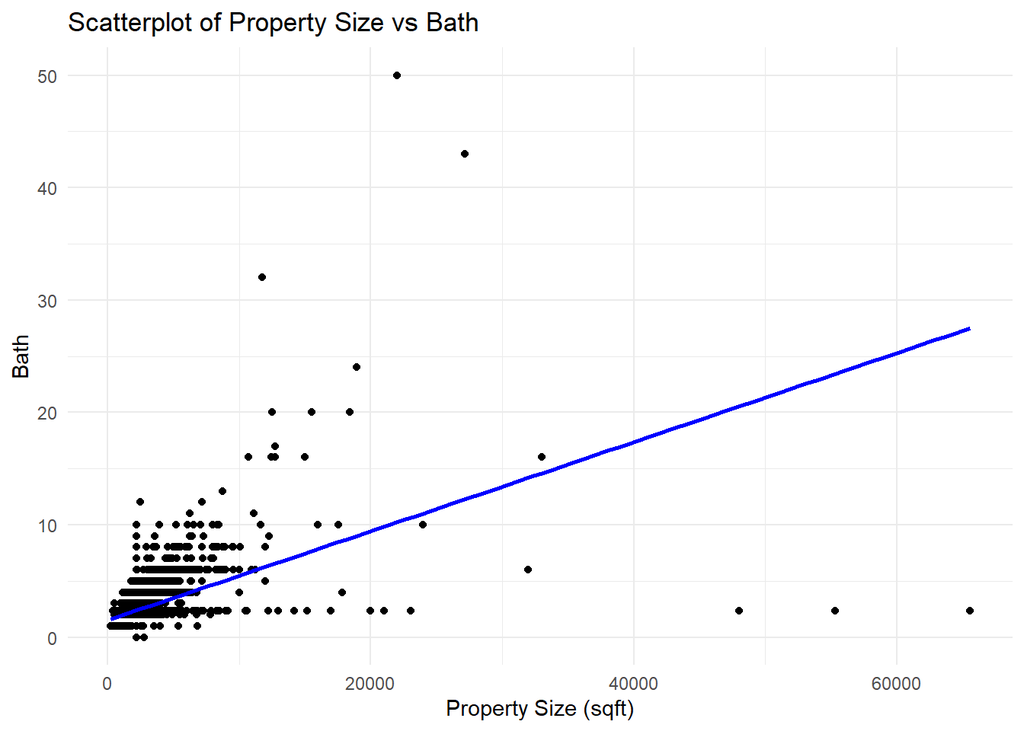

```r
# Scatterplot of PROPERTYSQFT vs BATH with best fit line
ggplot(NYHouse, aes(x = PROPERTYSQFT, y = BATH)) +
  geom_point() +
  geom_smooth(method = "lm", color = "blue", se = FALSE) +
  labs(title = "Scatterplot of Property Size vs Bath",
       x = "Property Size (sqft)",
       y = "Bath") +
  theme_minimal()
```

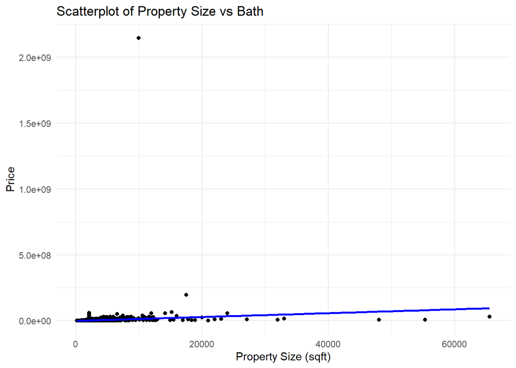

```r
# Scatterplot of PROPERTYSQFT vs PRICE with best fit line
ggplot(NYHouse, aes(x = PROPERTYSQFT, y = PRICE)) +
  geom_point() +
  geom_smooth(method = "lm", color = "blue", se = FALSE) +
  labs(title = "Scatterplot of Property Size vs Bath",
       x = "Property Size (sqft)",
       y = "Price") +
  theme_minimal()
```

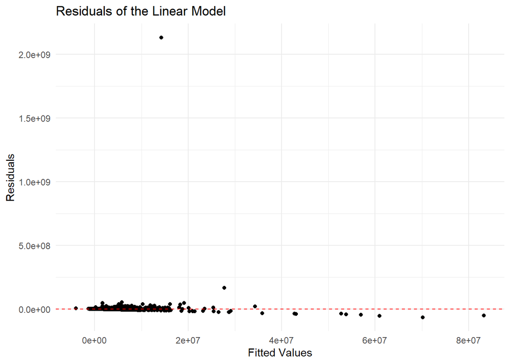

```r
# Plot the residuals
residuals <- model$residuals

# Residual plot
ggplot(NYHouse, aes(x = fitted(model), y = residuals)) +
  geom_point() +
  geom_hline(yintercept = 0, color = "red", linetype = "dashed") +
  labs(title = "Residuals of the Linear Model",
       x = "Fitted Values",
       y = "Residuals") +
  theme_minimal()
```

*The most significantly influencing variable for the house price is ’PROPERTYSQFT.’The residuals graph displays the errors for each data point over the fitted value. This graph explains that there is one outlier in the graph but the remaining values are smooth.*

## b) Derive a subset of the dataset according to any criteria (e.g. PRICE > VALUE or BEDS < NUMBER) and repeat the linear model with its plots. Explain how the significance of the input variables changes and your interpretation of the change. min. 2-3 sentences

```r
# Create a subset of the dataset where PRICE > 500000
subset_NYHouse <- subset(NYHouse, PRICE > 500000)

# Fit the linear model on the subset
model_subset <- lm(PRICE ~ BEDS + BATH + PROPERTYSQFT, data = subset_NYHouse)

# Summary of the new model
summary(model_subset)
```

```
##
## Call:
## lm(formula = PRICE ~ BEDS + BATH + PROPERTYSQFT, data = subset_NYHouse)
##
## Residuals:
##        Min         1Q     Median         3Q        Max
##  -66209514   -1722586    -841558      54097 2133012875
##
## Coefficients:
##               Estimate Std. Error t value Pr(>|t|)
## (Intercept)  -923721.4  1082784.2  -0.853   0.3937
## BEDS         -467250.8   333852.9  -1.400   0.1617
## BATH          936723.7   461375.6   2.030   0.0424 *
## PROPERTYSQFT    1304.5      256.4   5.087 3.83e-07 ***
## ---
## Signif. codes:  0 '***' 0.001 '**' 0.01 '*' 0.05 '.' 0.1 ' ' 1
##
## Residual standard error: 36260000 on 3538 degrees of freedom
## Multiple R-squared:  0.01254,    Adjusted R-squared:  0.0117
## F-statistic: 14.98 on 3 and 3538 DF,  p-value: 1.094e-09
```

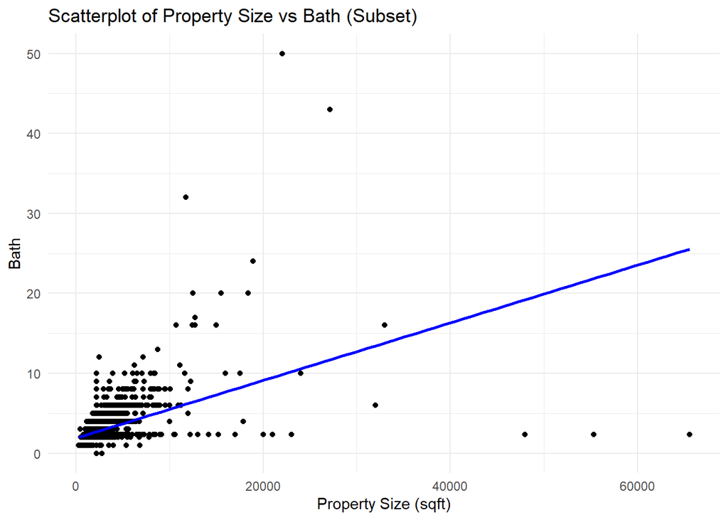

```r
# Scatterplot of PROPERTYSQFT vs BATH with best fit line for the subset
ggplot(subset_NYHouse, aes(x = PROPERTYSQFT, y = BATH)) +
  geom_point() +
  geom_smooth(method = "lm", color = "blue", se = FALSE) +
  labs(title = "Scatterplot of Property Size vs Bath (Subset)",
       x = "Property Size (sqft)",
       y = "Bath") +
  theme_minimal()
```

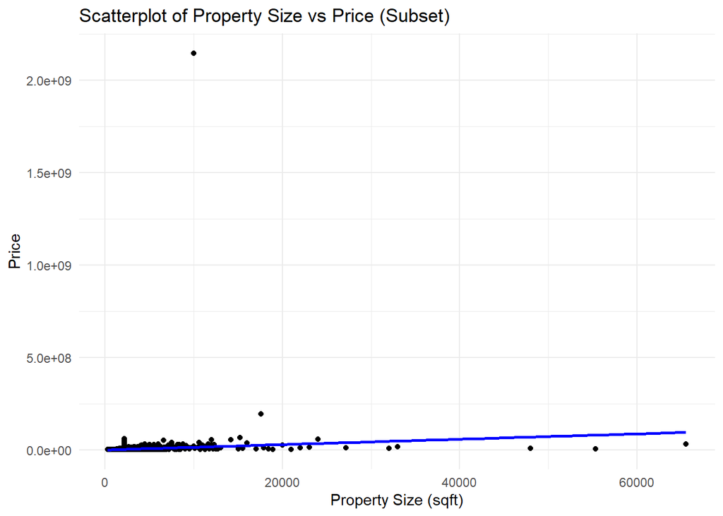

```r
# Scatterplot of PROPERTYSQFT vs PRICE with best fit line for the subset
ggplot(subset_NYHouse, aes(x = PROPERTYSQFT, y = PRICE)) +
  geom_point() +
  geom_smooth(method = "lm", color = "blue", se = FALSE) +
  labs(title = "Scatterplot of Property Size vs Price (Subset)",
       x = "Property Size (sqft)",
       y = "Price") +
  theme_minimal()
```

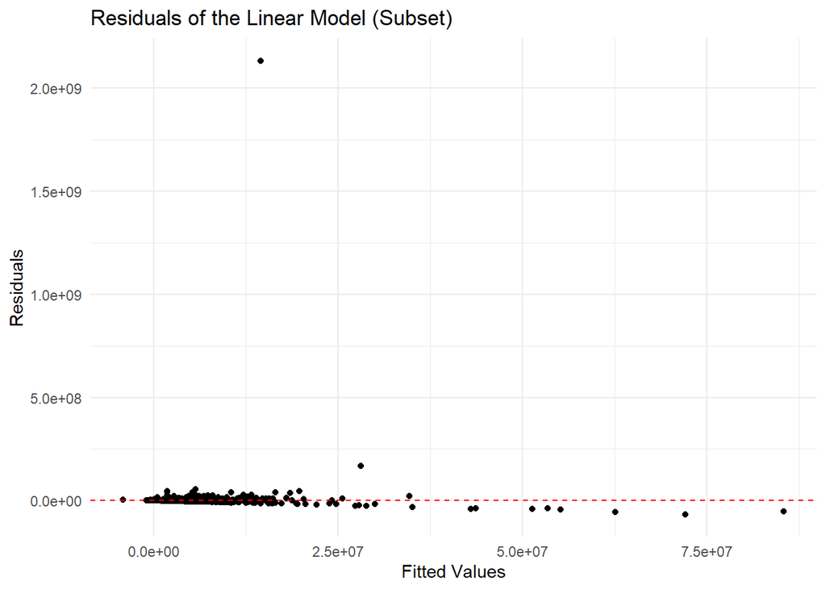

```r
# Plot the residuals for the subset
residuals_subset <- model_subset$residuals

# Residual plot for the subset
ggplot(subset_NYHouse, aes(x = fitted(model_subset), y = residuals_subset)) +
  geom_point() +
  geom_hline(yintercept = 0, color = "red", linetype = "dashed") +
  labs(title = "Residuals of the Linear Model (Subset)",
       x = "Fitted Values",
       y = "Residuals") +
  theme_minimal()
```

*Even after taking a subset of value PROPERTYSQFT is the most significant value. There is no significant change in the trend in graphs of the original and subset dataset. The residuals plot still has the outlier, this shows that the outlier value has PRICE > 500000*